# Maximização do lucro de uma empresa de produção caseira de geléias.

Documento criado por **Rodrigo Cesar Vertulo** em 06 de Agosto de 2020.

Este artigo visa apresentar um algoritmo genético para a maximização do lucro de uma empresa fictícia de produção caseira de geléias denominada "Sapore di Frutta".

Pesquisas realizadas pelos proprietários da empresa mostram que há demanda para a venda de até 100 unidades por mês do sabor "morango", 90 unidades do sabor "morango mais cítrico" e 50 unidades do sabor "uva".

Durante o mês a empresa tem a disposição 240 horas para dedicar-se à produção e o restante para atividades comerciais e administrativas. Com base nessas informações deseja-se definir a quantidade ideal a ser produzida de cada sabor para maximizar o lucro da empresa.

Atribuindo-se a variável x para quantidade produzida do sabor "morango", y para a quantidade produzida do sabor "morango mais cítrico" e z para a quantidade produzida do sabor "uva", deseja-se maximizar o lucro mensal da empresa que é dado por:

max L = 4x + 4.9y + 6z

Com base no potencial de vendas de cada sabor sabe-se que as seguintes restrições também devem ser respeitadas:

x <= 100

y <= 90

z <= 50

x, y e z >= 0

O algoritmo abaixo foi desenvolvido utilizando-se a linguagem de programação Python com a biblioteca para criação de Algoritmos Genéticos PyGARV

```
x =  94  y =  90  z =  14
Lucro =  901.0
x =  94  y =  90  z =  14
Lucro =  901.0
x =  89  y =  90  z =  17
Lucro =  899.0
```

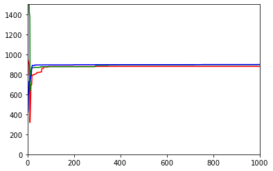

```python
%matplotlib inline

from PyGARV import *
import matplotlib.pyplot as plt

class SaporeDiFrutta(PyGARV):
    def __init__(self):
        super().__init__(popSize = 30,
                         values = 3,
                         mutationRate = 0.15,
                         elitism = 0,
                         digits = 3,
                         fullMutation = True,
                         symmetricCut = True)

        self.lucro = []

    def fitness(self, chromosome):
        x = chromosome[0]
        y = chromosome[1]
        z = chromosome[2]

        l = 4*x + 4.9*y + 6*z

        if (
            (1.15*x + 1.15*y + 2*z > 240) or
            x > 100 or
            y > 90 or
            z > 50 or
            (x*y*z == 0)
        ):

            nota = 1/(l+0.001)

        else:
            nota = l

        if nota == 0: nota = 0.001

        return [chromosome, nota]

    def finishedGeneration(self, chromosome):
        x = chromosome[0]
        y = chromosome[1]
        z = chromosome[2]

        l = 4*x + 4.9*y + 6*z

        self.lucro.append(l)


    def finishedGA(self, chromosome):
        x = chromosome[0]
        y = chromosome[1]
        z = chromosome[2]

        l = 4*x + 4.9*y + 6*z

        print("x = ", x, " y = ", y, " z = ", z)
        print("Lucro = ", l)

plt.axis([0,1000, 0, 1500])

pygarv1 = SaporeDiFrutta()
pygarv1.runGA(15000)

plt.plot(pygarv1.lucro, color='red')

pygarv2 = SaporeDiFrutta()
pygarv2.runGA(15000)

plt.plot(pygarv2.lucro, color='green')

pygarv3 = SaporeDiFrutta()
pygarv3.runGA(15000)

plt.plot(pygarv3.lucro, color='blue')
plt.show()
```

Foram executadas três simulações, cada uma com 15.000 gerações, e os resultados mostram que o plano de produção ideal contempla 94 unidades do sabor "morango", 90 do sabor "morango mais cítrico" e 14 do sabor "uva". Seguindo-se essa estratégia a Sapore Di Frutta potencialmente lucrará 901.00 unidades monetária.

# Conclusão

Pelo estudo apresentado nota-se que a utilização de Algoritmos Genéticos é uma boa alternativa para o planehamento de produção, facilitando sobremaneira a tarefa de identificar as quantidades ideais de produção dos itens, respeitando-se restrições inerentes à empresa, para a maximização do lucro potencial que a mesma poderá obter.